# Modularidade e Consequências Evolutivas

Daniela M. Rossoni

May 12, 2017

# Objetivos

Nessa aula prática vamos explorar como as associações entre caracteres morfológicos podem afetar os potenciais evolutivos das espécies. Para isso vamos utilizar as ferramentas analíticas desenvolvidas por Hansen & Houle (2008) apresentadas em aula teórica.

## Contextualização

Nas aulas práticas anteriores estimamos as matrizes de covariância e as matrizes de correlação para as cinco espécies presentes na base de dados dentus do pacote evolqg.

Observando as matrizes de correlação, nós detectamos alguns padrões modulares para cada espécie e discutimos como esses padrões diferem entre elas.

Além disso, calculamos o índice de magnitude de integração pra cada espécie. Lembrem-se que este índice é obtido a partir das matrizes de correlação como sendo a média dos coeficientes de correlação ao quadrado.

Na a aula de hoje nós vamos utilizar:

1. As matrizes de covariância por espécie;
2. As matrizes de correlação por espécie;
3. O índice de magnitude geral de integração por espécie;

Se vocês não salvaram os objetos criados no R nas aula anteriores, terão que rodar novamente as funções para obtê-los. Então vamos lá!

```r
# Carregando alguns pacotes

require (evolqg)
require (ggplot2)
require (dplyr)
require (magrittr)

# Carregando os dados que vamos utilizar em aula

data (dentus)
```

Calculando as matrizes de correlação para cada espécie:

```r
cor_A = cor(dentus[ dentus$species == "A", 1:4])
cor_B = cor(dentus[ dentus$species == "B", 1:4])
cor_C = cor(dentus[ dentus$species == "C", 1:4])
cor_D = cor(dentus[ dentus$species == "D", 1:4])
cor_E = cor(dentus[ dentus$species == "E", 1:4])
```

Calculando as matrizes de covariância para cada espécie:

```r
cov_A = cov(dentus[ dentus$species == "A", 1:4])
cov_B = cov(dentus[ dentus$species == "B", 1:4])
cov_C = cov(dentus[ dentus$species == "C", 1:4])
cov_D = cov(dentus[ dentus$species == "D", 1:4])
cov_E = cov(dentus[ dentus$species == "E", 1:4])
```

Calculando o índice da magnitude de integração para cada espécie

```r
R2_A = CalcR2(cor_A)
R2_B = CalcR2(cor_B)
R2_C = CalcR2(cor_C)
R2_D = CalcR2(cor_D)
R2_E = CalcR2(cor_E)
```

Agora vamos rodar a função que faz aqueles plots de correlação:

```r
library(ggplot2)
library(reshape2)
if(!require(viridis)) install.packages("viridis")
library(viridis)
plotMatrix <- function (corMat, file = NULL) {
        diag(corMat) <- NA
        n_traits = nrow(corMat)
        myPalette <- viridis(50)
        ## Se quiser uma paleta All American, use essa linha em vez da anterior
        #myPalette <- colorRampPalette(c("blue", "white", "red"))(n = 50)
        m.rs = melt(corMat)
        m.rs$Var1 <- factor(m.rs$Var1, levels = m.rs$Var1[n_traits:1])
        m.rs.position = m.rs
        m.rs.position$Var1 <- as.numeric(m.rs.position$Var1)
        m.rs.position$Var2 <- as.numeric(m.rs.position$Var2)
        m.rs.position$value= round(m.rs.position$value, 2)
        m.rs.position$value[is.na(m.rs.position$value)] <- levels(m.rs$Var1)[n_traits:1]
        p <-
                ggplot (m.rs) +
                geom_tile(aes(x = Var2, y = Var1, fill = value)) +
                scale_fill_gradientn(name = '', colours = myPalette, limits = c(-0.15, 1)) +
                labs(x = NULL, y = NULL) +
                geom_text(data = m.rs.position, aes(x = Var2, y = Var1, label = value)) +
                theme_bw()
        if(!is.null(file)) cowplot::save_plot(plot = p, file)
        return(p)
}
```

E finalmente, vamos olhar atentamente cada um dos plots de correlação e os respectivos valores de magnitude de integração calculados.

Espécie A

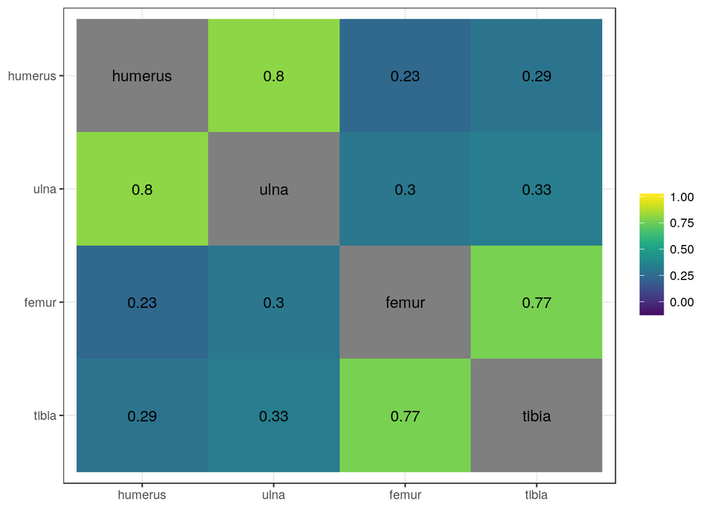

```r
plotMatrix(cor_A)
```

```r
CalcR2(cor_A)
```

```
## [1] 0.2630422
```

Faça a mesma coisa para o restante das espécies!

A função MeanMatrix Statistics do pacote pode ser utilizada para calcular todas as métricas de consequências evolutivas que exploramos em aula teórica, tais como flexibilidade, restrição, evolvabilidade e respondabilidade.

Mas antes de calcularmos todas estas métricas, vamos discutir alguns pontos tendo como ponto de partida os resultados que geramos há pouco.

## Questões

Já que sabemos os valores de magnitude de integração geral, o grau de modularidade de cada uma das espécies, e que temos embasamento teórico sobre o tema, quais são as nossas expectativas em relação às consequências evolutivas para cada espécie?

Por exemplo, para a espécie E que é muito desintegrada, qual é a expectativa em termos de suas flexibilidades e restrições evolutivas?

E para a espécie D?

## Estimativas das consequências evolutivas

Agora utilize a função Mean Matrix statistics e avalie os resultados encontrados para cada espécie comparando-os com suas expectativas.

Explore a função no help para compreender quais os argumentos que a função recebe e o que ela calcula:

```r
?MeanMatrixStatistics
```

Percebam que ela calcula também o índice de magnitude geral de integração. Certamente você está se perguntando agora: “Mas esse índice não é calculado com a matriz de correlação? A função pede a matriz de covariância… algo deve estar errado”.

Ótima observação! Mas não se preocupe pois internamente para algumas estimativas, a funçao transforma a matriz de covariância em uma matriz de correlação utilizando a função cov2cor.

Agora sim, você pode calcular as métricas para cada espécie da seguinte maneira:

```r
MMS_A <- MeanMatrixStatistics(cov_A, iterations = 1000, full.results = F, parallel = FALSE)
```

Mas se quiser, você pode aplicar a função de uma vez para todas as espécies:

```r
        MMS_total <- dlply(dentus, ~ species, '[', 1:4) %>%
        llply(cov) %>%
        ldply(MeanMatrixStatistics, .id = 'Species')
```

```r
r2_flex <- ggplot(MMS_total, aes(x=MeanSquaredCorrelation, y=flexibility , colour = Species, label = Species), size=20)+ geom_point(size=3)+ theme_bw() + ylab("flexibilidade")+ xlab("magnitude de integracao")

r2_restr <-ggplot(MMS_total, aes(x=MeanSquaredCorrelation, y=constraints , colour = Species, label = Species), size=20)+ geom_point(size=3)+ theme_bw() + ylab("restricao")+ xlab("magnitude de integracao")

restr_flex <- ggplot(MMS_total, aes(x=constraints, y=flexibility , colour = Species, label = Species), size=20)+ geom_point(size=3)+ theme_bw() + ylab("flexibilidade")+ xlab("restricao")

restr_pc1 <- ggplot(MMS_total, aes(x=constraints, y=pc1.percent , colour = Species, label = Species), size=20)+ geom_point(size=3)+ theme_bw() + ylab("variacao PC1")+ xlab("restricao")

flex_pc1 <- ggplot(MMS_total, aes(x=flexibility, y=pc1.percent , colour = Species, label = Species), size=20)+ geom_point(size=3)+ theme_bw() + ylab("variacao PC1")+ xlab("flexibilidade")
```